# Study report: ACE inhibitor versus thiazide initiation and 365-day hospitalization, and the feasibility path that led to it

## What this is, and what it is not

This is a **programming and methods demonstration** on the CMS synthetic Medicare files (generated by Synthea). It shows claims processing, cohort building, feasibility assessment, a new-user active-comparator design, propensity score weighting, censoring weights, bootstrap intervals and reporting. The synthetic data come from disease modules, not from patients, so **no estimate in this report is a treatment effect or a real-world finding**, and CMS advises against scientific inference from these files. Dataset version 2888df05c7.

## 1. How the question changed: the feasibility narrative

The study began as a different question and changed twice because the data could not support it. Each step below is recorded in `docs/amendments.md` and the protocol history; numbers are read from the pipeline outputs.

[output not shown]

The first move (influenza to bronchitis) was made at the end of the profiling phase and is recorded in the protocol version history and `qc/feasibility_findings.md`; amendments are numbered from A-001, raised in the bronchitis phase.

## 2. Data, design and methods in brief

- **Data:** CMS Synthetic Medicare Enrollment, FFS Claims and PDE files, March 2015 to March 2023 (last claim date 2023-03-02); 9,179 beneficiaries. Part D covers 70.5% of person-months; 19.7% of fills have no RxNorm record (measure 1) and 20.8% have no RxNorm drug concept (measure 2; both defined in the README).
- **Design:** new users aged 65 or older with continuous Part A, B and D entitlement for 365 days, a hypertension diagnosis (I10-I16), no antihypertensive fill in the previous 365 days, and a first fill of an ACE inhibitor or a thiazide or thiazide-like diuretic. Time zero is the first fill. Details in the protocol and SAP.
- **Analysis:** propensity score, stabilized IPTW (truncated at the 1st and 99th percentile), weighted Kaplan-Meier and weighted pooled logistic regression, 500-resample bootstrap intervals; sensitivity analyses listed in the SAP.

## 3. Results (illustrative)

### Cohort

| Step | Criterion | Episodes | Persons | Persons removed |
| --- | --- | --- | --- | --- |
| 0 | Beneficiaries in the beneficiary files | – | 9,179 | – |
| 1 | Fill of an ACE inhibitor or thiazide/thiazide-like diuretic on/after 2016-03-01 (candidate index dates) | 57,338 | 3,916 | 5,263 |
| 2 | New user: no antihypertensive fill in days -365 to -1 | 10,639 | 3,561 | 355 |
| 3 | Age 65 or older on the index date | 6,162 | 2,156 | 1,405 |
| 4 | Continuous Part A+B+D from the month of day -365 through the index month | 4,793 | 1,604 | 552 |
| 5 | Hypertension diagnosis (I10-I16) in days -365 to 0 (A-009) | 3,294 | 1,424 | 180 |
| 6 | Not both study drugs filled on the index date | 2,259 | 1,142 | 282 |
| 7 | No other antihypertensive class filled on the index date (A-010) | 1,529 | 821 | 321 |
| 8 | No hospice claim in days -365 to -1 | 1,466 | 792 | 29 |
| 9 | No inpatient stay overlapping the index date | 1,458 | 790 | 2 |
| 10 | First qualifying episode per beneficiary (final cohort) | 790 | 790 | 0 |

The final cohort has 790 people: ACE inhibitor 433 and thiazide 357. The hypertension-diagnosis requirement removed 180 people. The attrition table was re-derived independently in pandas (identical at every step) and in SAS (run in SAS OnDemand on 2026-10-21: all 11 attrition rows and all 10 baseline-count rows match the R output; see `qc/sas_reconciliation.md`).

### Balance

Before weighting the largest absolute standardized mean difference was 0.59; after IPTW it was 0.09 (target below 0.10; 0 of 30 covariate columns at or above 0.10). The propensity score c-statistic was 0.71; effective sample sizes after weighting were ACE inhibitor 329 and thiazide 306, and 16 weights were truncated.

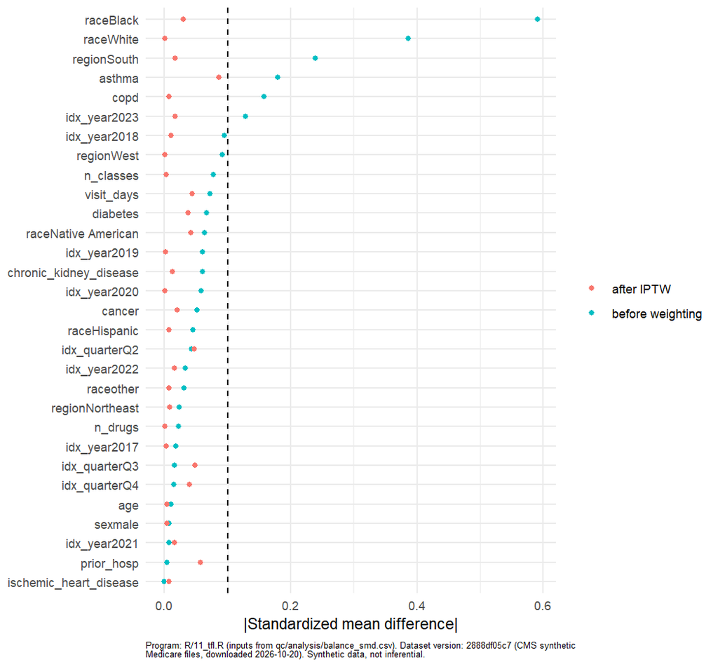

### Primary and secondary outcomes

Crude hospitalization events within 365 days: ACE inhibitor 78 and thiazide 60 (ACE inhibitor: 433; thiazide: 357 people).

| Method | Horizon | ACE inhibitor risk % | Thiazide risk % | Risk difference, points | Risk ratio |
| --- | --- | --- | --- | --- | --- |
| weighted pooled logistic, 365-day model read at day 30 | 30 days | 2.2 (95% CI 0.9 to 3.7) | 2.4 (95% CI 1.1 to 4.0) | -0.2 (95% CI -2.3 to 1.8) | 0.93 (95% CI 0.29 to 2.36) |
| weighted pooled logistic | 365 days | 21.4 (95% CI 16.4 to 26.4) | 17.7 (95% CI 13.6 to 22.0) | 3.8 (95% CI -3.5 to 9.4) | 1.21 (95% CI 0.84 to 1.62) |
| weighted pooled logistic | 30 days | 3.3 (95% CI 1.4 to 5.4) | 2.5 (95% CI 1.1 to 4.3) | 0.9 (95% CI -2.1 to 3.4) | 1.35 (95% CI 0.46 to 3.29) |
| weighted KM | 365 days | 21.4 (95% CI 16.4 to 26.4) | 17.7 (95% CI 13.6 to 22.0) | 3.8 (95% CI -3.5 to 9.4) | 1.21 (95% CI 0.84 to 1.61) |
| weighted KM | 30 days | 3.3 (95% CI 1.4 to 5.4) | 2.5 (95% CI 1.1 to 4.3) | 0.9 (95% CI -2.1 to 3.4) | 1.35 (95% CI 0.46 to 3.30) |

In the weighted Kaplan-Meier analysis the 365-day risk was 21.4% for the ACE inhibitor arm and 17.7% for the thiazide arm: a risk difference of 3.8 (95% CI -3.5 to 9.4) percentage points and a risk ratio of 1.21 (95% CI 0.84 to 1.61). The interval for the risk difference includes zero. The weighted pooled logistic model gave a 365-day risk ratio of 1.21. The E-value for the point estimate is 1.72 and 1.00 for the confidence limit. For the secondary 30-day outcome the weighted pooled logistic model was fitted to days 1-30 only (A-014), because a 4-df spline over 365 days cannot resolve the first-month hazard; it gave a risk ratio of 1.35, against 0.93 when the 365-day model is read at day 30 (both are in T5). The risk difference was 0.9 (95% CI -2.1 to 3.4) percentage points (weighted Kaplan-Meier); the 30-day analysis rests on few events (ACE inhibitor 11 and thiazide 10), so it is unstable.

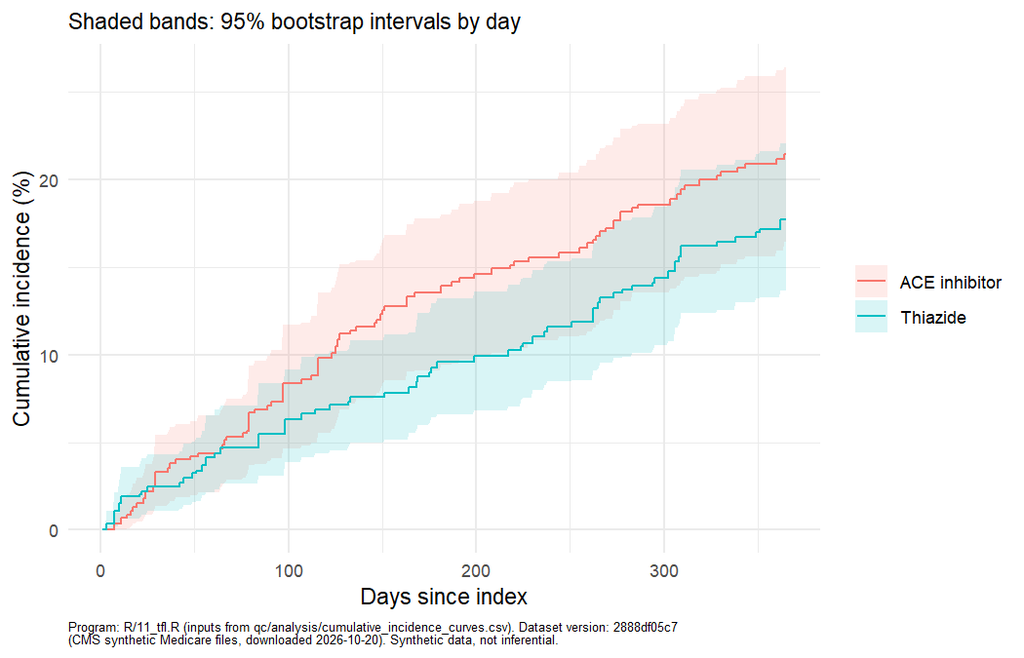

### Sensitivity analyses

| Analysis | N | ACE inhibitor risk % | Thiazide risk % | RD, points | RR |
| --- | --- | --- | --- | --- | --- |
| Primary: IPTW, ITT, follow-up to loss of A/B/D, end of data 2023-03-31 | 790 | 21.4 | 17.7 | 3.8 (95% CI -3.5 to 9.4) | 1.21 (95% CI 0.84 to 1.61) |
| Unadjusted (no weights) | 790 | 19.7 | 18.2 | 1.5 (95% CI -4.4 to 6.6) | 1.08 (95% CI 0.79 to 1.43) |
| Untruncated weights | 790 | 21.5 | 17.7 | 3.8 (95% CI -3.0 to 11.0) | 1.21 (95% CI 0.84 to 1.70) |
| PS matching 1:1, caliper 0.2 SD of the logit (matched sample, ATT) | 552 | 20.8 | 17.5 | 3.4 (95% CI -4.5 to 9.2) | 1.19 (95% CI 0.79 to 1.60) |
| Keep other-class co-starters, indicator covariate (A-010) | 1,101 | 17.8 | 19.4 | -1.6 (95% CI -6.9 to 3.5) | 0.92 (95% CI 0.70 to 1.21) |
| Exclude any baseline fill with no RxNorm record (A-010) | 669 | 21.9 | 17.2 | 4.7 (95% CI -2.9 to 11.7) | 1.27 (95% CI 0.86 to 1.84) |
| Hypertension diagnosis only in days -365 to -1 (A-009) | 617 | 22.4 | 21.9 | 0.5 (95% CI -7.5 to 7.7) | 1.02 (95% CI 0.71 to 1.44) |
| ITT follow-up ignoring loss of Part D (A-008) | 790 | 21.4 | 17.5 | 3.9 (95% CI -2.7 to 9.4) | 1.22 (95% CI 0.85 to 1.61) |
| ITT follow-up v0.3 rule: last claim date 2023-03-02, Part A+B only (A-008) | 789 | 21.4 | 17.7 | 3.8 (95% CI -3.0 to 9.3) | 1.21 (95% CI 0.85 to 1.59) |
| Exclude chronic kidney disease | 629 | 20.5 | 16.4 | 4.1 (95% CI -2.9 to 10.7) | 1.25 (95% CI 0.84 to 1.84) |
| IPCW for loss of Part A/B/D entitlement, primary ITT outcome (A-013) | 790 | 21.4 | 17.7 | 3.7 (95% CI -3.6 to 9.3) | 1.21 (95% CI 0.83 to 1.61) |
| Add-on/switch-censored with IPCW (A-007) | 790 | 21.8 | 18.0 | 3.8 (95% CI -3.6 to 9.5) | 1.21 (95% CI 0.84 to 1.61) |

Across the 11 sensitivity analyses, every 95% interval for the risk ratio includes 1.0; the point estimate of the risk ratio was above 1 in 10 and below 1 in 1 of them (primary analysis: 1.21; range across sensitivity analyses 0.92 to 1.27). The analysis furthest from the primary risk ratio on the log scale is “Keep other-class co-starters, indicator covariate (A-010)” (1101 people, risk ratio 0.92). The IPCW analysis for loss of Part A/B/D entitlement used 75 censoring events (IPCW multipliers 0.9284 to 1.1882).

### Negative control, treatment patterns and refills

| Arm | N | Fracture events | Person-years |
| --- | --- | --- | --- |
| ACE inhibitor | 433 | 1 | 393.3 |
| thiazide | 357 | 1 | 327.2 |

The negative control (hip or femur fracture) is reported descriptively only: ACE inhibitor 1 and thiazide 1 events, too few to interpret (counts below 11 are not interpretable).

| Arm | N | Add-on | Switch | Discontinued | Index days supply (median) |
| --- | --- | --- | --- | --- | --- |
| ACE inhibitor | 433 | 8 | 1 | 401 | 90 |
| thiazide | 357 | 7 | 2 | 327 | 90 |

Add-on or switch to the other study drug was rare (ACE inhibitor 9 and thiazide 9 people). Most people have a single 90-day fill followed by a second fill about a year later (649 of 790 have a second fill, median 371 days), which is why discontinuation does not censor any analysis.

## 4. Limitations and what not to conclude

- The data are synthetic: relationships between drugs, conditions and hospitalizations come from the generator, not from biology. Do not read any estimate as evidence about ACE inhibitors or thiazides.
- 20.8% of fills have no RxNorm drug concept (measure 2) and 19.7% have no RxNorm record (measure 1), so new-user status and exposure can be misclassified; a sensitivity analysis removes people with a baseline fill that has no RxNorm record.
- ED visits are not observable; hospitalization means any inpatient admission.
- The same background drug bundle (including ACE inhibitors and thiazides) appears across all conditions in the generator, so indication-specific confounding is unlike real practice.
- Follow-up ends when Part D entitlement is lost (Part D coverage is patchy); two sensitivity analyses address this.
- Event counts are modest, intervals are wide, and the 30-day analysis is unstable.

## 5. Reproducibility

Programs in `R/`, SQL in `sql/`, code lists in `codelists/`, tests in `tests/`, continuous integration in `.github/workflows/ci.yml`. SAS reconciliation (`sas/cohort_qc.sas`) was run in SAS OnDemand on 2026-10-21 with all attrition and baseline rows matching R (`qc/sas_reconciliation.md`); it is not part of CI. Every table, figure and listing in `output/tfl/` names its generating program and the dataset version.